# FinalProject

2022-11-22

# Data Preparation

## Summary

```r
summary(data)
```

```
##     school              sex                 age         address
##  Length:395         Length:395         Min.   :15.0   Length:395
##  Class :character   Class :character   1st Qu.:16.0   Class :character
##  Mode  :character   Mode  :character   Median :17.0   Mode  :character
##                                        Mean   :16.7
##                                        3rd Qu.:18.0
##                                        Max.   :22.0
##    famsize            Pstatus               Medu            Fedu
##  Length:395         Length:395         Min.   :0.000   Min.   :0.000
##  Class :character   Class :character   1st Qu.:2.000   1st Qu.:2.000
##  Mode  :character   Mode  :character   Median :3.000   Median :2.000
##                                        Mean   :2.749   Mean   :2.522
##                                        3rd Qu.:4.000   3rd Qu.:3.000
##                                        Max.   :4.000   Max.   :4.000
##      Mjob               Fjob              reason            guardian
##  Length:395         Length:395         Length:395         Length:395
##  Class :character   Class :character   Class :character   Class :character
##  Mode  :character   Mode  :character   Mode  :character   Mode  :character
##
##
##
##    traveltime      studytime        failures       schoolsup
##  Min.   :1.000   Min.   :1.000   Min.   :0.0000   Length:395
##  1st Qu.:1.000   1st Qu.:1.000   1st Qu.:0.0000   Class :character
##  Median :1.000   Median :2.000   Median :0.0000   Mode  :character
##  Mean   :1.448   Mean   :2.035   Mean   :0.3342
##  3rd Qu.:2.000   3rd Qu.:2.000   3rd Qu.:0.0000
##  Max.   :4.000   Max.   :4.000   Max.   :3.0000
##     famsup              paid            activities          nursery
##  Length:395         Length:395         Length:395         Length:395
##  Class :character   Class :character   Class :character   Class :character
##  Mode  :character   Mode  :character   Mode  :character   Mode  :character
##
##
##
##     higher            internet           romantic             famrel
##  Length:395         Length:395         Length:395         Min.   :1.000
##  Class :character   Class :character   Class :character   1st Qu.:4.000
##  Mode  :character   Mode  :character   Mode  :character   Median :4.000
##                                                           Mean   :3.944
```

[output cut: 8 more lines]

```
##  Max.   :5.000   Max.   :5.000   Max.   :5.000   Max.   :5.000
##      health         absences            G1              G2
##  Min.   :1.000   Min.   : 0.000   Min.   : 3.00   Min.   : 0.00
##  1st Qu.:3.000   1st Qu.: 0.000   1st Qu.: 8.00   1st Qu.: 9.00
##  Median :4.000   Median : 4.000   Median :11.00   Median :11.00
##  Mean   :3.554   Mean   : 5.709   Mean   :10.91   Mean   :10.71
##  3rd Qu.:5.000   3rd Qu.: 8.000   3rd Qu.:13.00   3rd Qu.:13.00
##  Max.   :5.000   Max.   :75.000   Max.   :19.00   Max.   :19.00
##        G3
##  Min.   : 0.00
##  1st Qu.: 8.00
##  Median :11.00
##  Mean   :10.42
##  3rd Qu.:14.00
##  Max.   :20.00
```

## Dimensions

```r
dim(data)
```

```
## [1] 395  33
```

## Missing Values

```r
sum(is.na(data))
```

```
## [1] 0
```

## Type of data

```r
print(str(data))
```

```
## 'data.frame':    395 obs. of  33 variables:
##  $ school    : chr  "GP" "GP" "GP" "GP" ...
##  $ sex       : chr  "F" "F" "F" "F" ...
##  $ age       : int  18 17 15 15 16 16 16 17 15 15 ...
##  $ address   : chr  "U" "U" "U" "U" ...
##  $ famsize   : chr  "GT3" "GT3" "LE3" "GT3" ...
##  $ Pstatus   : chr  "A" "T" "T" "T" ...
##  $ Medu      : int  4 1 1 4 3 4 2 4 3 3 ...
##  $ Fedu      : int  4 1 1 2 3 3 2 4 2 4 ...
##  $ Mjob      : chr  "at_home" "at_home" "at_home" "health" ...
##  $ Fjob      : chr  "teacher" "other" "other" "services" ...
##  $ reason    : chr  "course" "course" "other" "home" ...
##  $ guardian  : chr  "mother" "father" "mother" "mother" ...
##  $ traveltime: int  2 1 1 1 1 1 1 2 1 1 ...
##  $ studytime : int  2 2 2 3 2 2 2 2 2 2 ...
```

[output cut: 20 more lines]

# Data Exploration(EDA)

## Histogram

We will do some histograms to have a better understanding of the data used.

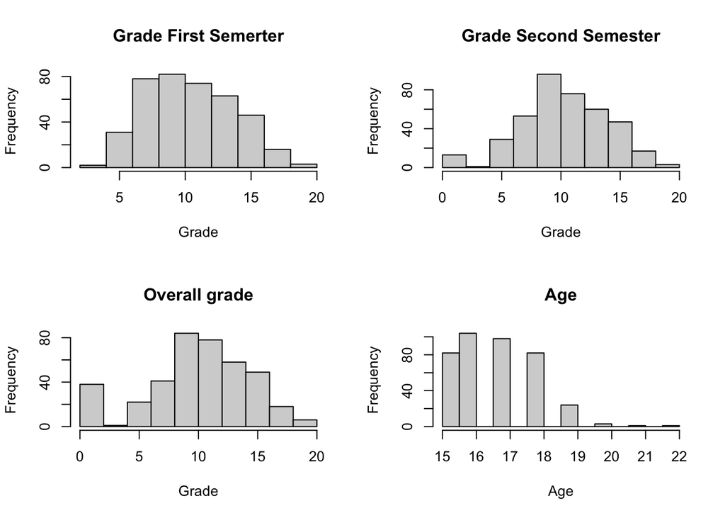

```r
par(mfrow = c(2, 2))

#Histogram of Petal Width with 10 bins
hist(data$G1,
          main="Grade First Semerter",
          xlab="Grade")

hist(data$G2,
          main="Grade Second Semester",
          xlab="Grade")

hist(data$G3,
          main="Overall grade",
          xlab="Grade")

hist(data$age,
          main="Age",
          xlab="Age")
```

## Barplot

Since we have a lot of columns with defined variables, it is interesting to make some barplots so we can get a better uderstanding of the dataset.

### Barplots related to studying

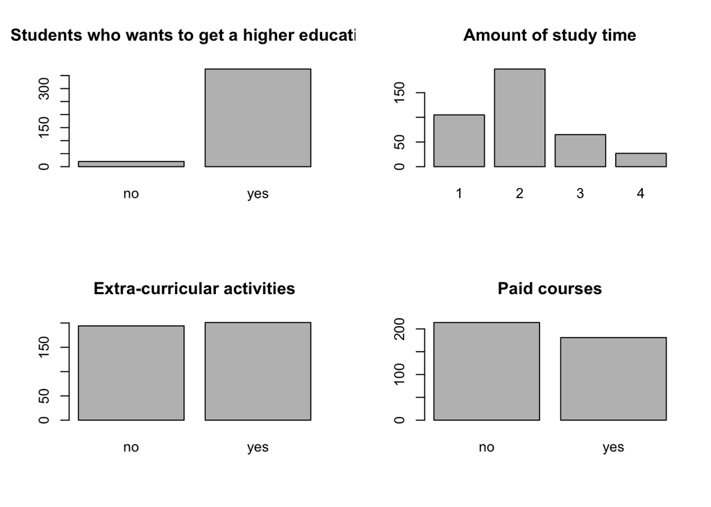

```r
par(mfrow = c(2, 2))

barplot(table(data$higher),  main="Students who wants to get a higher education")
barplot(table(data$studytime), main = "Amount of study time")
barplot(table(data$activities), main = "Extra-curricular activities")
barplot(table(data$paid), main = "Paid courses")
```

### Barplots related to drinking

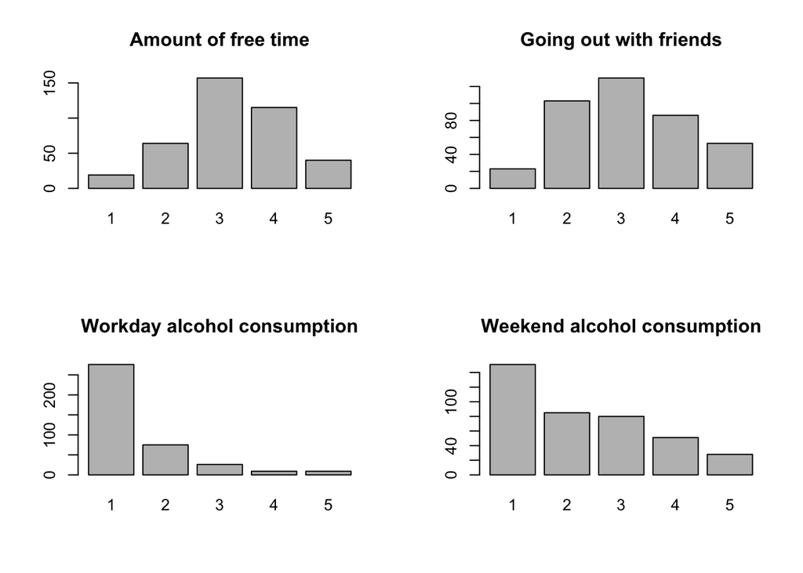

```r
par(mfrow = c(2, 2))
barplot(table(data$freetime),  main="Amount of free time")
barplot(table(data$goout), main = "Going out with friends")
barplot(table(data$Dalc), main = "Workday alcohol consumption")
barplot(table(data$Walc), main = "Weekend alcohol consumption")
```

## Boxplots

Now that we undertand our dataset a little bit, we will do some boxplots to analyze is some of our data have outliers and/or if the values are spread out or not.

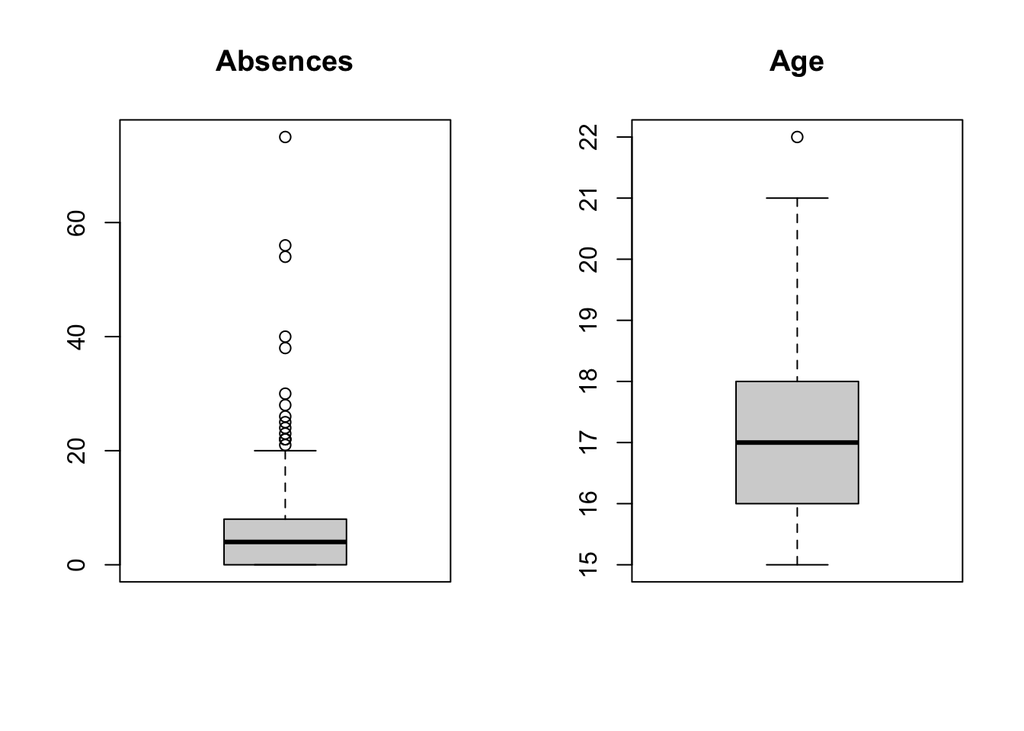

```r
par(mfrow = c(1, 2))

boxplot(data$absences, main = "Absences")
boxplot(data$age, main = "Age")
```

## Histogram with overlay

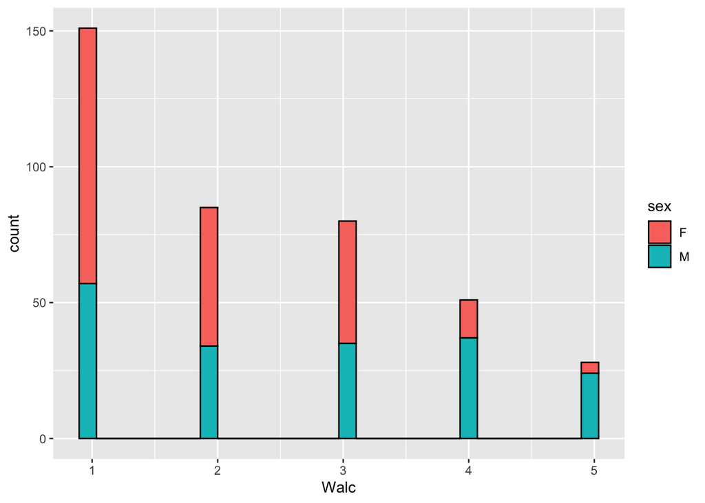

```r
ggplot(data = data, aes(x = Walc)) +
  geom_histogram(aes(fill = sex), bins = 30, color = "black")
```

## Other graphs with overlay

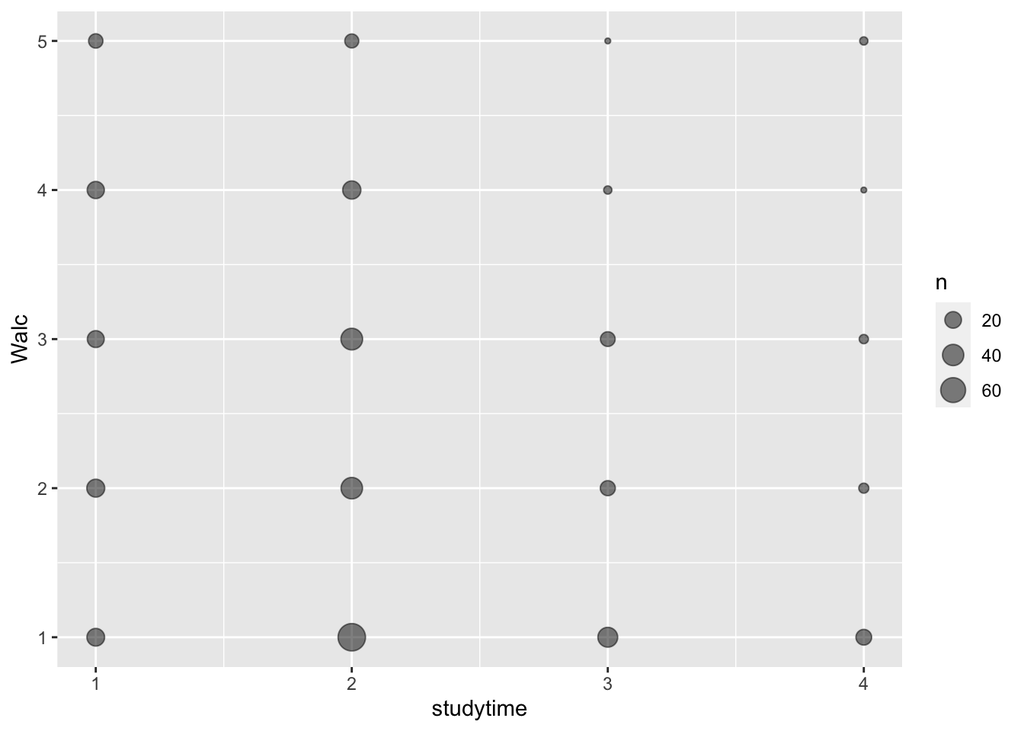

```r
ggplot(data, aes(x = studytime, y = Walc)) +
  geom_count(alpha = 0.5)
```

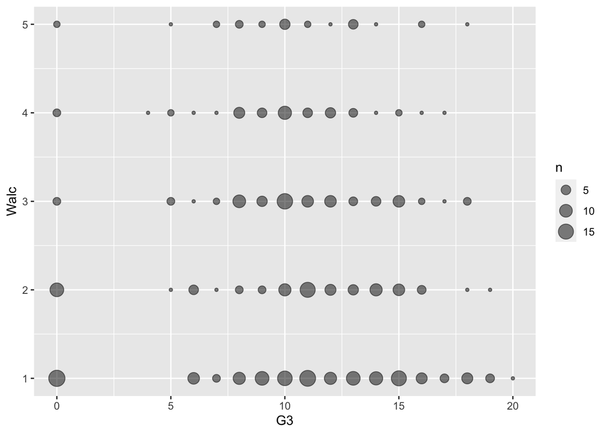

```r
ggplot(data, aes(x = G3, y = Walc)) +
  geom_count(alpha = 0.5)
```

# Data Analysis

## Hypothesis Testing

```r
alcohol <- data[c('age','failures', 'sex', 'G2', 'G3', 'Dalc', 'Walc', 'studytime', 'failures', 'goout')]
str(alcohol)
```

```
## 'data.frame':    395 obs. of  10 variables:
##  $ age       : int  18 17 15 15 16 16 16 17 15 15 ...
##  $ failures  : int  0 0 3 0 0 0 0 0 0 0 ...
##  $ sex       : chr  "F" "F" "F" "F" ...
##  $ G2        : int  6 5 8 14 10 15 12 5 18 15 ...
##  $ G3        : int  6 6 10 15 10 15 11 6 19 15 ...
##  $ Dalc      : int  1 1 2 1 1 1 1 1 1 1 ...
##  $ Walc      : int  1 1 3 1 2 2 1 1 1 1 ...
##  $ studytime : int  2 2 2 3 2 2 2 2 2 2 ...
##  $ failures.1: int  0 0 3 0 0 0 0 0 0 0 ...
##  $ goout     : int  4 3 2 2 2 2 4 4 2 1 ...
```

### Effect of alcohol on grades

h0: Mean of grade of people who drink more = Mean of grade of people who drink less h1: Mean of people who drink more != Mean of people who drink less

```r
less <- alcohol[alcohol['Walc'] < 3,]
more <- alcohol[alcohol['Walc'] > 2,]
t.test(more$G3, less$G3)
```

```
##
##  Welch Two Sample t-test
##
## data:  more$G3 and less$G3
## t = -0.47396, df = 389.38, p-value = 0.6358
## alternative hypothesis: true difference in means is not equal to 0
## 95 percent confidence interval:
##  -1.0846814  0.6632977
## sample estimates:
## mean of x mean of y
##  10.28931  10.50000
```

### Effect of study time on grades

h0: Mean of grades of people who study more = Mean of grades of people who study less h1: Mean of grades of people who study more != Mean of grades of people who study less

```r
less <- alcohol[alcohol['studytime'] < 3,]
more <- alcohol[alcohol['studytime'] > 2,]
t.test(more$G3, less$G3)
```

```
##
##  Welch Two Sample t-test
##
## data:  more$G3 and less$G3
## t = 2.1831, df = 142.32, p-value = 0.03067
## alternative hypothesis: true difference in means is not equal to 0
## 95 percent confidence interval:
##  0.1162353 2.3437303
## sample estimates:
## mean of x mean of y
##  11.35870  10.12871
```

### Relation between failure and drinking

h0: Mean of alcohol of people who fail more = Mean of alcohol of people who fail less h1: Mean of alcohol of people who fail more != Mean of alcohol of people who fail less

```r
less <- alcohol[alcohol['failures'] < 3,]
more <- alcohol[alcohol['failures'] > 2,]
t.test(more$Walc, less$Walc)
```

```
##
##  Welch Two Sample t-test
##
## data:  more$Walc and less$Walc
## t = 1.5742, df = 15.714, p-value = 0.1354
## alternative hypothesis: true difference in means is not equal to 0
## 95 percent confidence interval:
##  -0.2348536  1.5821491
## sample estimates:
## mean of x mean of y
##  2.937500  2.263852
```

### Relation between gender and drinking

h0: Mean of alcohol of woman = Mean of alcohol of men h1: Mean of alcohol of woman != Mean of alcohol of men

```r
female <- alcohol[alcohol['sex'] == 'F',]
male <- alcohol[alcohol['sex'] == 'M',]
t.test(female$Walc, male$Walc)
```

```
##
##  Welch Two Sample t-test
##
## data:  female$Walc and male$Walc
## t = -5.5666, df = 341.41, p-value = 5.263e-08
## alternative hypothesis: true difference in means is not equal to 0
## 95 percent confidence interval:
##  -0.9559649 -0.4567768
## sample estimates:
## mean of x mean of y
##  1.956731  2.663102
```

## Linear regression model

### Forward Stepwise

```r
# Create a null model
intercept_only <- lm(G3 ~ 1, data=data)
# Create a full model
all <- lm(G3~., data=data)
# perform forward step-wise regression
forward <- stepAIC (intercept_only, direction='forward',scope = formula(all))
```

```
## Start:  AIC=1203.39
## G3 ~ 1
##
##              Df Sum of Sq    RSS     AIC
## + G2          1    6771.3 1498.6  530.70
## + G1          1    5312.2 2957.7  799.25
## + failures    1    1074.3 7195.7 1150.43
## + Medu        1     390.0 7880.0 1186.31
## + higher      1     275.3 7994.6 1192.01
## + age         1     215.9 8054.0 1194.94
## + Fedu        1     192.2 8077.7 1196.10
## + Mjob        4     306.6 7963.3 1196.46
## + goout       1     145.8 8124.1 1198.36
## + romantic    1     139.7 8130.2 1198.66
## + traveltime  1     113.5 8156.4 1199.93
## + address     1      92.5 8177.4 1200.95
## + sex         1      88.5 8181.4 1201.14
## + paid        1      86.0 8183.9 1201.26
## + internet    1      80.2 8189.7 1201.54
## + studytime   1      79.1 8190.8 1201.59
## + schoolsup   1      56.7 8213.2 1202.67
## + famsize     1      54.8 8215.1 1202.76
## + reason      3     129.9 8140.0 1203.14
## <none>                    8269.9 1203.39
## + health      1      31.1 8238.8 1203.90
## + Pstatus     1      27.8 8242.1 1204.06
## + guardian    2      66.6 8203.3 1204.20
## + Dalc        1      24.7 8245.2 1204.21
## + Walc        1      22.3 8247.6 1204.32
## + nursery     1      22.0 8247.9 1204.34
## + famrel      1      21.8 8248.1 1204.35
## + school      1      16.8 8253.1 1204.59
## + famsup      1      12.7 8257.2 1204.78
## + absences    1       9.7 8260.2 1204.93
## + activities  1       2.1 8267.8 1205.29
## + freetime    1       1.1 8268.9 1205.34
## + Fjob        4     109.1 8160.9 1206.15
##
## Step:  AIC=530.7
## G3 ~ G2
```

[output cut: 281 more lines]

```
## + traveltime  1    1.2457 1336.8 503.55
## + Medu        1    1.1679 1336.8 503.57
## + nursery     1    1.1527 1336.8 503.58
## + Pstatus     1    1.1134 1336.9 503.59
## + sex         1    0.9004 1337.1 503.65
## + higher      1    0.7921 1337.2 503.68
## + Fedu        1    0.7102 1337.3 503.71
## + paid        1    0.6183 1337.4 503.73
## + famsize     1    0.2163 1337.8 503.85
## + goout       1    0.1263 1337.9 503.88
## + address     1    0.0228 1338.0 503.91
## + guardian    2    5.6634 1332.3 504.24
## + Fjob        4   16.5231 1321.5 505.01
## + reason      3    9.3473 1328.7 505.15
## + Mjob        4    0.5407 1337.5 509.76
```

```r
forward$anova
```

```
## Stepwise Model Path
## Analysis of Deviance Table
##
## Initial Model:
## G3 ~ 1
##
## Final Model:
## G3 ~ G2 + famrel + absences + G1 + age + activities + Walc +
##     romantic + school
##
##
##            Step Df    Deviance Resid. Df Resid. Dev       AIC
## 1                                    394   8269.909 1203.3897
## 2          + G2  1 6771.286242       393   1498.623  530.6993
## 3      + famrel  1   38.146748       392   1460.476  522.5146
## 4    + absences  1   36.191684       391   1424.284  514.6029
## 5          + G1  1   23.791388       390   1400.493  509.9490
## 6         + age  1   24.396348       389   1376.096  505.0075
## 7  + activities  1   12.522754       388   1363.574  503.3965
## 8        + Walc  1   10.284707       387   1353.289  502.4059
## 9    + romantic  1    8.395341       386   1344.894  501.9479
## 10     + school  1    6.897784       385   1337.996  501.9167
```

### Model

```r
summary(forward)
```

```
##
## Call:
## lm(formula = G3 ~ G2 + famrel + absences + G1 + age + activities +
##     Walc + romantic + school, data = data)
##
## Residuals:
##     Min      1Q  Median      3Q     Max
## -8.8416 -0.4534  0.2645  1.0247  4.0315
##
## Coefficients:
##               Estimate Std. Error t value Pr(>|t|)
## (Intercept)    0.65012    1.45806   0.446 0.655933
## G2             0.96153    0.04904  19.607  < 2e-16 ***
## famrel         0.38361    0.10668   3.596 0.000365 ***
## absences       0.04714    0.01232   3.826 0.000152 ***
## G1             0.18058    0.05517   3.273 0.001159 **
## age           -0.26017    0.08405  -3.095 0.002109 **
## activitiesyes -0.32049    0.18989  -1.688 0.092278 .
## Walc           0.11979    0.07521   1.593 0.112050
## romanticyes   -0.32668    0.20622  -1.584 0.113989
## schoolMS       0.45495    0.32293   1.409 0.159693
## ---
## Signif. codes:  0 '***' 0.001 '**' 0.01 '*' 0.05 '.' 0.1 ' ' 1
##
## Residual standard error: 1.864 on 385 degrees of freedom
## Multiple R-squared:  0.8382, Adjusted R-squared:  0.8344
## F-statistic: 221.6 on 9 and 385 DF,  p-value: < 2.2e-16
```

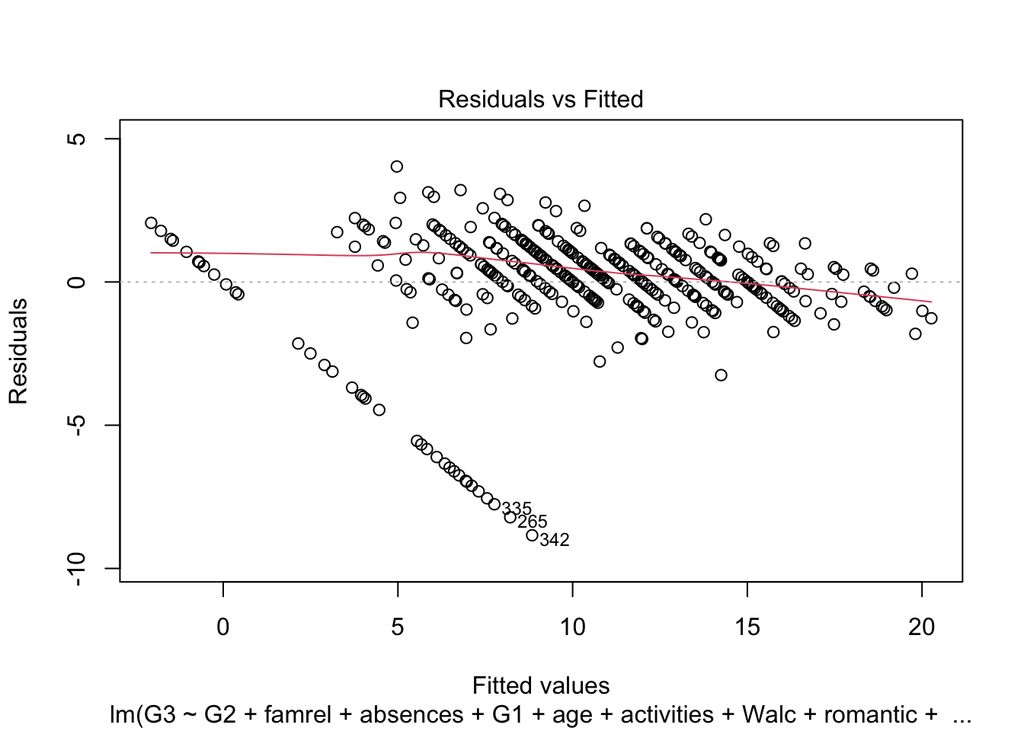

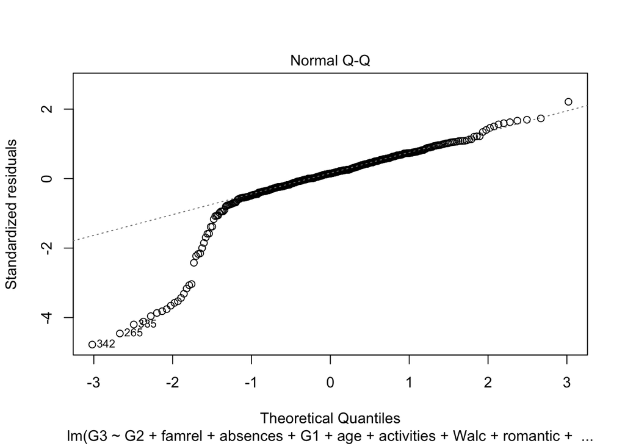

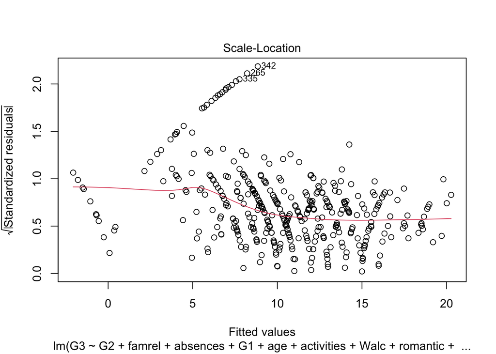

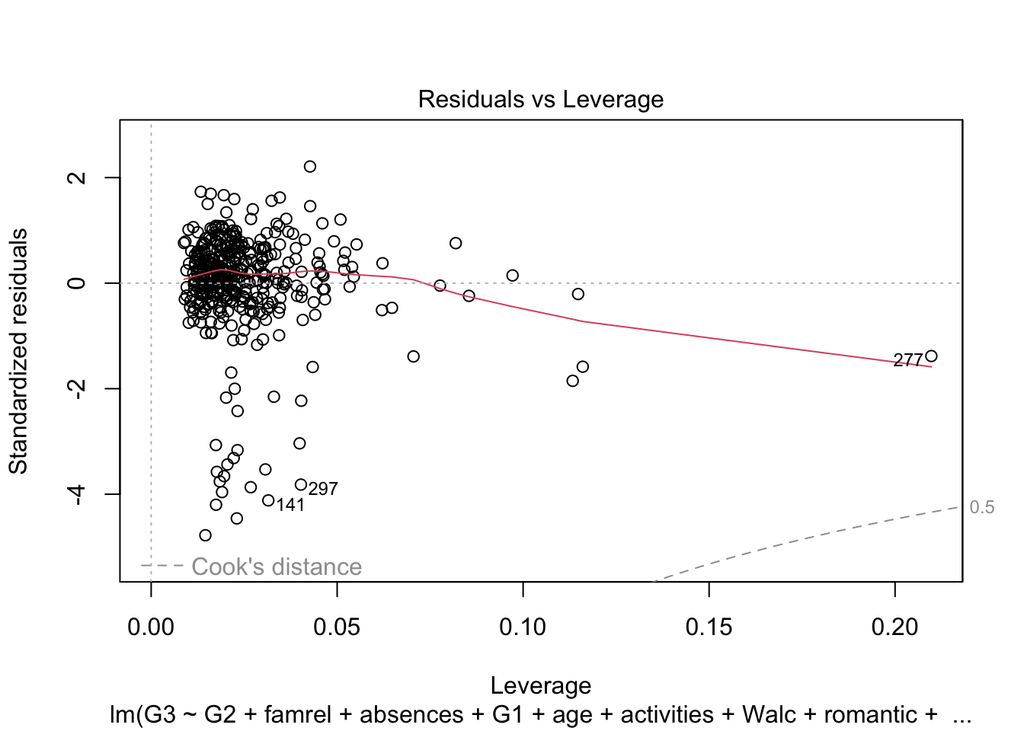

```r
plot(forward)
```

### MAE and MSE

```r
ypred_forward <- predict(object = forward, newdata = data)
MAE(y_pred = ypred_forward, y_true = data$G3)
```

```
## [1] 1.171571
```

```r
MSE(y_pred = ypred_forward, y_true = data$G3)
```

```
## [1] 3.387331
```